# Исследование интернет-магазина "Стримчик"

Вы работаете в интернет-магазине «Стримчик», который продаёт по всему миру компьютерные игры. Из открытых источников доступны исторические данные о продажах игр, оценки пользователей и экспертов, жанры и платформы (например, Xbox или PlayStation). Вам нужно выявить определяющие успешность игры закономерности. Это позволит сделать ставку на потенциально популярный продукт и спланировать рекламные кампании. Перед вами данные до 2016 года. Представим, что сейчас декабрь 2016 г., и вы планируете кампанию на 2017-й. Нужно отработать принцип работы с данными. Неважно, прогнозируете ли вы продажи на 2017 год по данным 2016-го или же 2027-й — по данным 2026 года. В наборе данных попадается аббревиатура ESRB (Entertainment Software Rating Board) — это ассоциация, определяющая возрастной рейтинг компьютерных игр. ESRB оценивает игровой контент и присваивает ему подходящую возрастную категорию, например, «Для взрослых», «Для детей младшего возраста» или «Для подростков».

**План исследования**

1. Откройте файл с данными и изучите общую информацию
2. Подготовьте данные
3. Проведите исследовательский анализ данных
4. Составьте портрет пользователя каждого региона
5. Проверьте гипотезы
6. Напишите общий вывод

**Описание данных**

- Name — название игры
- Platform — платформа
- Year_of_Release — год выпуска
- Genre — жанр игры
- NA_sales — продажи в Северной Америке (миллионы проданных копий)
- EU_sales — продажи в Европе (миллионы проданных копий)
- JP_sales — продажи в Японии (миллионы проданных копий)
- Other_sales — продажи в других странах (миллионы проданных копий)
- Critic_Score — оценка критиков (максимум 100)
- User_Score — оценка пользователей (максимум 10)
- Rating — рейтинг от организации ESRB (англ. Entertainment Software Rating Board). Эта ассоциация определяет рейтинг --компьютерных игр и присваивает им подходящую возрастную категорию.

## Откройте файл с данными и изучите общую информацию

### Импортируем необходимые для работы библиотеки

```python
import pandas as pd
from scipy import stats as st
import matplotlib.pyplot as plt
import numpy as np
import seaborn as sns
```

### Загрузка данных

```python
try:
    data = pd.read_csv('/datasets/games.csv.')
except:
    data = pd.read_csv('https://code.s3.yandex.net/datasets/games.csv')
```

### Изучим общую информацию

```python
data.info()
```

```
<class 'pandas.core.frame.DataFrame'>
RangeIndex: 16715 entries, 0 to 16714
Data columns (total 11 columns):
 #   Column           Non-Null Count  Dtype
---  ------           --------------  -----
 0   Name             16713 non-null  object
 1   Platform         16715 non-null  object
 2   Year_of_Release  16446 non-null  float64
 3   Genre            16713 non-null  object
 4   NA_sales         16715 non-null  float64
 5   EU_sales         16715 non-null  float64
 6   JP_sales         16715 non-null  float64
 7   Other_sales      16715 non-null  float64
 8   Critic_Score     8137 non-null   float64
 9   User_Score       10014 non-null  object
 10  Rating           9949 non-null   object
dtypes: float64(6), object(5)
memory usage: 1.4+ MB
```

```python
data.head(10)
```

|  | Name | Platform | Year_of_Release | Genre | NA_sales | EU_sales | JP_sales | Other_sales | Critic_Score | User_Score | Rating |
| --- | --- | --- | --- | --- | --- | --- | --- | --- | --- | --- | --- |
| 0 | Wii Sports | Wii | 2006.0 | Sports | 41.36 | 28.96 | 3.77 | 8.45 | 76.0 | 8 | E |
| 1 | Super Mario Bros. | NES | 1985.0 | Platform | 29.08 | 3.58 | 6.81 | 0.77 | NaN | NaN | NaN |
| 2 | Mario Kart Wii | Wii | 2008.0 | Racing | 15.68 | 12.76 | 3.79 | 3.29 | 82.0 | 8.3 | E |
| 3 | Wii Sports Resort | Wii | 2009.0 | Sports | 15.61 | 10.93 | 3.28 | 2.95 | 80.0 | 8 | E |
| 4 | Pokemon Red/Pokemon Blue | GB | 1996.0 | Role-Playing | 11.27 | 8.89 | 10.22 | 1.00 | NaN | NaN | NaN |
| 5 | Tetris | GB | 1989.0 | Puzzle | 23.20 | 2.26 | 4.22 | 0.58 | NaN | NaN | NaN |
| 6 | New Super Mario Bros. | DS | 2006.0 | Platform | 11.28 | 9.14 | 6.50 | 2.88 | 89.0 | 8.5 | E |
| 7 | Wii Play | Wii | 2006.0 | Misc | 13.96 | 9.18 | 2.93 | 2.84 | 58.0 | 6.6 | E |
| 8 | New Super Mario Bros. Wii | Wii | 2009.0 | Platform | 14.44 | 6.94 | 4.70 | 2.24 | 87.0 | 8.4 | E |
| 9 | Duck Hunt | NES | 1984.0 | Shooter | 26.93 | 0.63 | 0.28 | 0.47 | NaN | NaN | NaN |

```python
data.describe().T
```

|  | count | mean | std | min | 25% | 50% | 75% | max |
| --- | --- | --- | --- | --- | --- | --- | --- | --- |
| Year_of_Release | 16446.0 | 2006.484616 | 5.877050 | 1980.0 | 2003.0 | 2007.00 | 2010.00 | 2016.00 |
| NA_sales | 16715.0 | 0.263377 | 0.813604 | 0.0 | 0.0 | 0.08 | 0.24 | 41.36 |
| EU_sales | 16715.0 | 0.145060 | 0.503339 | 0.0 | 0.0 | 0.02 | 0.11 | 28.96 |
| JP_sales | 16715.0 | 0.077617 | 0.308853 | 0.0 | 0.0 | 0.00 | 0.04 | 10.22 |
| Other_sales | 16715.0 | 0.047342 | 0.186731 | 0.0 | 0.0 | 0.01 | 0.03 | 10.57 |
| Critic_Score | 8137.0 | 68.967679 | 13.938165 | 13.0 | 60.0 | 71.00 | 79.00 | 98.00 |

```python
data.isna().mean()
```

```
Name               0.000120
Platform           0.000000
Year_of_Release    0.016093
Genre              0.000120
NA_sales           0.000000
EU_sales           0.000000
JP_sales           0.000000
Other_sales        0.000000
Critic_Score       0.513192
User_Score         0.400897
Rating             0.404786
dtype: float64
```

```python
data.duplicated().sum()
```

```
0
```

**Первичный вывод:**

- Необходимо привести столбцы к нижнему регистру
- Необходимо изменить тип данных в стобах Year_of_Release, critic_score, user_score
- Имеется большое кол-во пропусков в колонках Critic_Score (51% пропусков), Rating (40,5% пропусков), User_Score (40% пропусков).
- Дубликаты не выявлены

## Подготовка данных

### Заменим название столбцов(приведем к нижнему регистру и заменим пробелы)

```python
data.columns
```

```
Index(['Name', 'Platform', 'Year_of_Release', 'Genre', 'NA_sales', 'EU_sales',
       'JP_sales', 'Other_sales', 'Critic_Score', 'User_Score', 'Rating'],
      dtype='object')
```

```python
data.columns = [c.lower().replace(' ', '_') for c in data.columns]
```

```python
data.columns
```

```
Index(['name', 'platform', 'year_of_release', 'genre', 'na_sales', 'eu_sales',
       'jp_sales', 'other_sales', 'critic_score', 'user_score', 'rating'],
      dtype='object')
```

### Преобразуем данные в нужные типы

```python
data.info()
```

```
<class 'pandas.core.frame.DataFrame'>
RangeIndex: 16715 entries, 0 to 16714
Data columns (total 11 columns):
 #   Column           Non-Null Count  Dtype
---  ------           --------------  -----
 0   name             16713 non-null  object
 1   platform         16715 non-null  object
 2   year_of_release  16446 non-null  float64
 3   genre            16713 non-null  object
 4   na_sales         16715 non-null  float64
 5   eu_sales         16715 non-null  float64
 6   jp_sales         16715 non-null  float64
 7   other_sales      16715 non-null  float64
 8   critic_score     8137 non-null   float64
 9   user_score       10014 non-null  object
 10  rating           9949 non-null   object
dtypes: float64(6), object(5)
memory usage: 1.4+ MB
```

#### Изменим тип данных в столбце year_of_release на int

Нет возможности изменить тип данных так как присувствуют пропуски, исследуем их

```python
data['year_of_release'].isna().sum()
```

```
269
```

```python
data['year_of_release'].unique()
```

```
array([2006., 1985., 2008., 2009., 1996., 1989., 1984., 2005., 1999.,
       2007., 2010., 2013., 2004., 1990., 1988., 2002., 2001., 2011.,
       1998., 2015., 2012., 2014., 1992., 1997., 1993., 1994., 1982.,
       2016., 2003., 1986., 2000.,   nan, 1995., 1991., 1981., 1987.,
       1980., 1983.])
```

```python
#Удалим пустые значения т.к. их немного и они не повлияют на результат
data.dropna(subset=['year_of_release'], inplace=True)
```

```python
data['year_of_release'].unique()
```

```
array([2006., 1985., 2008., 2009., 1996., 1989., 1984., 2005., 1999.,
       2007., 2010., 2013., 2004., 1990., 1988., 2002., 2001., 2011.,
       1998., 2015., 2012., 2014., 1992., 1997., 1993., 1994., 1982.,
       2016., 2003., 1986., 2000., 1995., 1991., 1981., 1987., 1980.,
       1983.])
```

```python
#Изменим тип данных на int
data['year_of_release'] = data['year_of_release'].astype('int')
```

```python
data['year_of_release'].unique()
```

```
array([2006, 1985, 2008, 2009, 1996, 1989, 1984, 2005, 1999, 2007, 2010,
       2013, 2004, 1990, 1988, 2002, 2001, 2011, 1998, 2015, 2012, 2014,
       1992, 1997, 1993, 1994, 1982, 2016, 2003, 1986, 2000, 1995, 1991,
       1981, 1987, 1980, 1983])
```

#### Исследование данных в столбце critic_score

```python
data['critic_score'].head(10)
```

```
0    76.0
1     NaN
2    82.0
3    80.0
4     NaN
5     NaN
6    89.0
7    58.0
8    87.0
9     NaN
Name: critic_score, dtype: float64
```

```python
data['critic_score'].unique()
```

```
array([76., nan, 82., 80., 89., 58., 87., 91., 61., 97., 95., 77., 88.,
       83., 94., 93., 85., 86., 98., 96., 90., 84., 73., 74., 78., 92.,
       71., 72., 68., 62., 49., 67., 81., 66., 56., 79., 70., 59., 64.,
       75., 60., 63., 69., 50., 25., 42., 44., 55., 48., 57., 29., 47.,
       65., 54., 20., 53., 37., 38., 33., 52., 30., 32., 43., 45., 51.,
       40., 46., 39., 34., 41., 36., 31., 27., 35., 26., 19., 28., 23.,
       24., 21., 17., 13.])
```

```python
data['critic_score'].isna().sum()
```

```
8463
```

```python
#data['critic_score'] = data['critic_score'].astype('int64')
```

Пропусков слишком много, следовательно критики могли еще не оценить данные игры, заполнять их не будем

#### Исследование данных в столбце user_score

```python
data['user_score'].head(10)
```

```
0      8
1    NaN
2    8.3
3      8
4    NaN
5    NaN
6    8.5
7    6.6
8    8.4
9    NaN
Name: user_score, dtype: object
```

```python
data['user_score'].unique()
```

```
array(['8', nan, '8.3', '8.5', '6.6', '8.4', '8.6', '7.7', '6.3', '7.4',
       '8.2', '9', '7.9', '8.1', '8.7', '7.1', '3.4', '5.3', '4.8', '3.2',
       '8.9', '6.4', '7.8', '7.5', '2.6', '7.2', '9.2', '7', '7.3', '4.3',
       '7.6', '5.7', '5', '9.1', '6.5', 'tbd', '8.8', '6.9', '9.4', '6.8',
       '6.1', '6.7', '5.4', '4', '4.9', '4.5', '9.3', '6.2', '4.2', '6',
       '3.7', '4.1', '5.8', '5.6', '5.5', '4.4', '4.6', '5.9', '3.9',
       '3.1', '2.9', '5.2', '3.3', '4.7', '5.1', '3.5', '2.5', '1.9', '3',
       '2.7', '2.2', '2', '9.5', '2.1', '3.6', '2.8', '1.8', '3.8', '0',
       '1.6', '9.6', '2.4', '1.7', '1.1', '0.3', '1.5', '0.7', '1.2',
       '2.3', '0.5', '1.3', '0.2', '0.6', '1.4', '0.9', '1', '9.7'],
      dtype=object)
```

Мы обнаружили аббревиатуру 'tbd', что означает рейтинг не определен. Можно просто заменить на nan

```python
data.loc[data['user_score'] == 'tbd', 'user_score'] = np.nan
```

```python
data['user_score'].unique()
```

```
array(['8', nan, '8.3', '8.5', '6.6', '8.4', '8.6', '7.7', '6.3', '7.4',
       '8.2', '9', '7.9', '8.1', '8.7', '7.1', '3.4', '5.3', '4.8', '3.2',
       '8.9', '6.4', '7.8', '7.5', '2.6', '7.2', '9.2', '7', '7.3', '4.3',
       '7.6', '5.7', '5', '9.1', '6.5', '8.8', '6.9', '9.4', '6.8', '6.1',
       '6.7', '5.4', '4', '4.9', '4.5', '9.3', '6.2', '4.2', '6', '3.7',
       '4.1', '5.8', '5.6', '5.5', '4.4', '4.6', '5.9', '3.9', '3.1',
       '2.9', '5.2', '3.3', '4.7', '5.1', '3.5', '2.5', '1.9', '3', '2.7',
       '2.2', '2', '9.5', '2.1', '3.6', '2.8', '1.8', '3.8', '0', '1.6',
       '9.6', '2.4', '1.7', '1.1', '0.3', '1.5', '0.7', '1.2', '2.3',
       '0.5', '1.3', '0.2', '0.6', '1.4', '0.9', '1', '9.7'], dtype=object)
```

```python
data['user_score'].isna().sum()
```

```
8983
```

Пропусков слишком много, следовательно пользователи могли еще не оценить данные игры, заполнять их не будем

```python
data['user_score'] = data['user_score'].astype('float')
```

```python
data.info()
```

```
<class 'pandas.core.frame.DataFrame'>
Int64Index: 16446 entries, 0 to 16714
Data columns (total 11 columns):
 #   Column           Non-Null Count  Dtype
---  ------           --------------  -----
 0   name             16444 non-null  object
 1   platform         16446 non-null  object
 2   year_of_release  16446 non-null  int64
 3   genre            16444 non-null  object
 4   na_sales         16446 non-null  float64
 5   eu_sales         16446 non-null  float64
 6   jp_sales         16446 non-null  float64
 7   other_sales      16446 non-null  float64
 8   critic_score     7983 non-null   float64
 9   user_score       7463 non-null   float64
 10  rating           9768 non-null   object
dtypes: float64(6), int64(1), object(4)
memory usage: 1.5+ MB
```

#### Исследование данных в столбце rating

```python
data['rating'].head(10)
```

```
0      E
1    NaN
2      E
3      E
4    NaN
5    NaN
6      E
7      E
8      E
9    NaN
Name: rating, dtype: object
```

```python
data['rating'].unique()
```

```
array(['E', nan, 'M', 'T', 'E10+', 'K-A', 'AO', 'EC', 'RP'], dtype=object)
```

```python
data['rating'].isna().sum()
```

```
6678
```

Пропусков слишком много, заполнять не будем т.к. нам неизвестен рейтинг данных игр

#### Посчитайте суммарные продажи во всех регионах и запишите их в отдельный столбец.

```python
data['world_sales'] = (data['na_sales'] + data['eu_sales']
                                   + data['jp_sales'] + data['other_sales'])
data.head()
```

|  | name | platform | year_of_release | genre | na_sales | eu_sales | jp_sales | other_sales | critic_score | user_score | rating | world_sales |
| --- | --- | --- | --- | --- | --- | --- | --- | --- | --- | --- | --- | --- |
| 0 | Wii Sports | Wii | 2006 | Sports | 41.36 | 28.96 | 3.77 | 8.45 | 76.0 | 8.0 | E | 82.54 |
| 1 | Super Mario Bros. | NES | 1985 | Platform | 29.08 | 3.58 | 6.81 | 0.77 | NaN | NaN | NaN | 40.24 |
| 2 | Mario Kart Wii | Wii | 2008 | Racing | 15.68 | 12.76 | 3.79 | 3.29 | 82.0 | 8.3 | E | 35.52 |
| 3 | Wii Sports Resort | Wii | 2009 | Sports | 15.61 | 10.93 | 3.28 | 2.95 | 80.0 | 8.0 | E | 32.77 |
| 4 | Pokemon Red/Pokemon Blue | GB | 1996 | Role-Playing | 11.27 | 8.89 | 10.22 | 1.00 | NaN | NaN | NaN | 31.38 |

**Вывод:**

- получилось много пропусков в столбцах rating, critic_score, user_score. С ними мы пока ничего не можем сделать, потому что игры могут быть новыми, которые не успели оценить критики и пользователи. Эти данные нельзя просто так отбросить, потому что ещё могут пригодиться для дальнейшего анализа.
- Данные в столбце year_of_release привели к INT.
- Создан новый столбец data['world_sales']

## Проведите исследовательский анализ данных

### Посмотрите, сколько игр выпускалось в разные годы. Важны ли данные за все периоды?

```python
data['year_of_release'].sort_values().unique()
```

```
array([1980, 1981, 1982, 1983, 1984, 1985, 1986, 1987, 1988, 1989, 1990,
       1991, 1992, 1993, 1994, 1995, 1996, 1997, 1998, 1999, 2000, 2001,
       2002, 2003, 2004, 2005, 2006, 2007, 2008, 2009, 2010, 2011, 2012,
       2013, 2014, 2015, 2016])
```

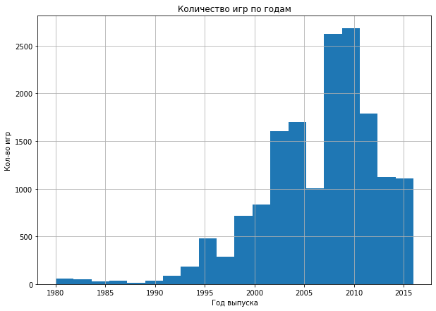

```python
data['year_of_release'].hist(bins=20, range=[1980,2016], figsize=(10,7))
plt.grid(True)
plt.title('Количество игр по годам')
plt.xlabel('Год выпуска')
plt.ylabel('Кол-во игр')
```

```python
release_pivot = data.pivot_table(index='year_of_release', values='world_sales', aggfunc='count')
release_pivot
```

| year_of_release | world_sales |
| --- | --- |
| 1980 | 9 |
| 1981 | 46 |
| 1982 | 36 |
| 1983 | 17 |
| 1984 | 14 |
| 1985 | 14 |
| 1986 | 21 |
| 1987 | 16 |
| 1988 | 15 |
| 1989 | 17 |
| 1990 | 16 |
| 1991 | 41 |
| 1992 | 43 |
| 1993 | 62 |
| 1994 | 121 |
| 1995 | 219 |
| 1996 | 263 |
| 1997 | 289 |
| 1998 | 379 |
| 1999 | 338 |
| 2000 | 350 |
| 2001 | 482 |
| 2002 | 829 |
| 2003 | 775 |
| 2004 | 762 |
| 2005 | 939 |
| 2006 | 1006 |
| 2007 | 1197 |
| 2008 | 1427 |
| 2009 | 1426 |
| 2010 | 1255 |
| 2011 | 1136 |
| 2012 | 653 |
| 2013 | 544 |
| 2014 | 581 |
| 2015 | 606 |
| 2016 | 502 |

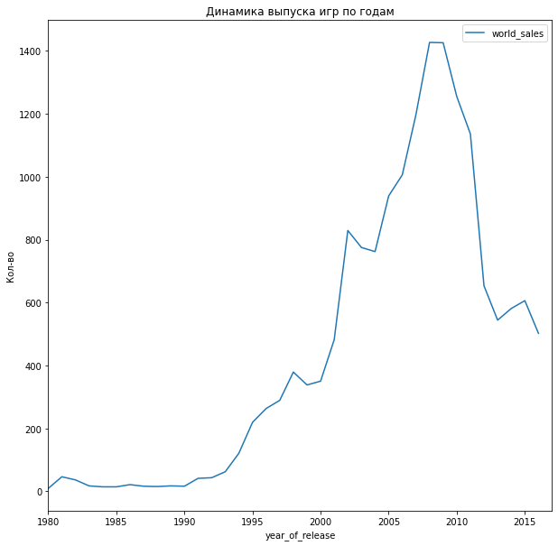

```python
release_pivot.plot(title='Динамика выпуска игр по годам', ylabel='Кол-во',figsize=(10,10),xlim=([1980,2017]))
```

Игры выпускались с 1980 года, но до 1995 их было слишком мало. Построим гистограмму с 1995 года

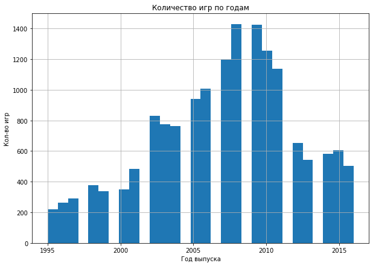

```python
data['year_of_release'].hist(bins=30, range=(1995,2016), figsize=(10,7))
plt.grid(True)
plt.title('Количество игр по годам')
plt.xlabel('Год выпуска')
plt.ylabel('Кол-во игр')
```

```python
data.year_of_release.value_counts().head(10)
```

```
2008    1427
2009    1426
2010    1255
2007    1197
2011    1136
2006    1006
2005     939
2002     829
2003     775
2004     762
Name: year_of_release, dtype: int64
```

**Вывод:**

- У нас есть данные по играм с 1980 по 2016
- До 1995 игр было слишком мало.
- Большо кол-во игр выпускалось с 2005 по 2011 года
- Максимальное кол-во игр пришлось на 2008 = 1427, 2009- 1426
- С 2011 года количество игр снизилось в среднем до 500-600
- Данные за все периоды важны, благодаря этому можно проследить динамику разработки игр.

### Данные о продажах по платформам

```python
data['platform'].unique()
```

```
array(['Wii', 'NES', 'GB', 'DS', 'X360', 'PS3', 'PS2', 'SNES', 'GBA',
       'PS4', '3DS', 'N64', 'PS', 'XB', 'PC', '2600', 'PSP', 'XOne',
       'WiiU', 'GC', 'GEN', 'DC', 'PSV', 'SAT', 'SCD', 'WS', 'NG', 'TG16',
       '3DO', 'GG', 'PCFX'], dtype=object)
```

```python
data_platform = data.pivot_table(index=['platform'], values='world_sales', aggfunc='sum').sort_values(by='world_sales',ascending = False)
data_platform
```

| platform | world_sales |
| --- | --- |
| PS2 | 1233.56 |
| X360 | 961.24 |
| PS3 | 931.34 |
| Wii | 891.18 |
| DS | 802.78 |
| PS | 727.58 |
| PS4 | 314.14 |
| GBA | 312.88 |
| PSP | 289.53 |
| 3DS | 257.81 |
| PC | 255.76 |
| GB | 254.43 |
| XB | 251.57 |
| NES | 251.05 |
| N64 | 218.01 |
| SNES | 200.04 |
| GC | 196.73 |
| XOne | 159.32 |
| 2600 | 86.48 |
| WiiU | 82.19 |
| PSV | 53.81 |
| SAT | 33.59 |
| GEN | 30.77 |
| DC | 15.95 |
| SCD | 1.86 |
| NG | 1.44 |
| WS | 1.42 |
| TG16 | 0.16 |
| 3DO | 0.10 |
| GG | 0.04 |
| PCFX | 0.03 |

Рассмотри 7 первых компаний по продаже

```
PS2
```

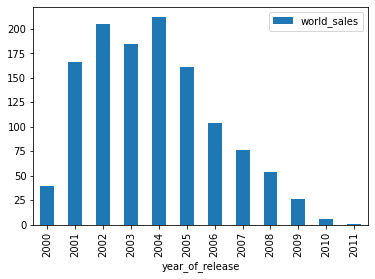

```
X360
```

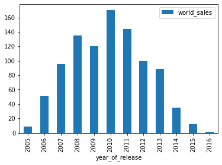

```
PS3
```

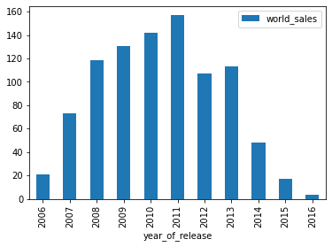

```
Wii
```

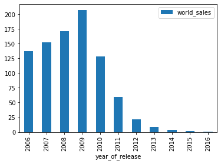

```
DS
```

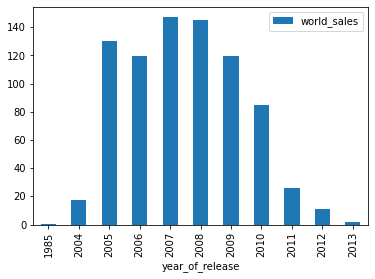

```
PS
```

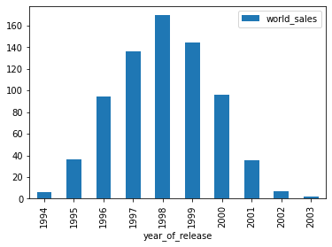

```
PS4
```

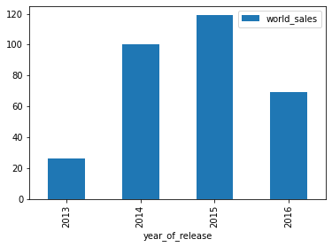

```python
for platform in data_platform.index[:7]:
    print(platform)
    (data.query('platform == @platform').pivot_table(index='year_of_release', values='world_sales', aggfunc='sum').plot(kind='bar')
    )
    plt.show()
```

**Вывод**

- Самая популярныая приставка на которую продано было максимальное кол-во игр это PS2. На момент появления данной приставки, не было аналогов и достойных конкурентов.

### Актуальные данные

Актуальными данными будем считать последние данные за 3 года с сохранением нынешнего для будущих анализов. Следовательно, нам надо оставить 2016 год, 2015 год и 2014 год, все, что было раньше – нас не интересует.

```python
actual_data = data.query('year_of_release >= 2014')
```

```python
actual_data.head(10)
```

|  | name | platform | year_of_release | genre | na_sales | eu_sales | jp_sales | other_sales | critic_score | user_score | rating | world_sales |
| --- | --- | --- | --- | --- | --- | --- | --- | --- | --- | --- | --- | --- |
| 31 | Call of Duty: Black Ops 3 | PS4 | 2015 | Shooter | 6.03 | 5.86 | 0.36 | 2.38 | NaN | NaN | NaN | 14.63 |
| 42 | Grand Theft Auto V | PS4 | 2014 | Action | 3.96 | 6.31 | 0.38 | 1.97 | 97.0 | 8.3 | M | 12.62 |
| 47 | Pokemon Omega Ruby/Pokemon Alpha Sapphire | 3DS | 2014 | Role-Playing | 4.35 | 3.49 | 3.10 | 0.74 | NaN | NaN | NaN | 11.68 |
| 77 | FIFA 16 | PS4 | 2015 | Sports | 1.12 | 6.12 | 0.06 | 1.28 | 82.0 | 4.3 | E | 8.58 |
| 87 | Star Wars Battlefront (2015) | PS4 | 2015 | Shooter | 2.99 | 3.49 | 0.22 | 1.28 | NaN | NaN | NaN | 7.98 |
| 92 | Call of Duty: Advanced Warfare | PS4 | 2014 | Shooter | 2.81 | 3.48 | 0.14 | 1.23 | 83.0 | 5.7 | M | 7.66 |
| 94 | FIFA 17 | PS4 | 2016 | Sports | 0.66 | 5.75 | 0.08 | 1.11 | 85.0 | 5.0 | E | 7.60 |
| 96 | Super Smash Bros. for Wii U and 3DS | 3DS | 2014 | Fighting | 3.27 | 1.37 | 2.43 | 0.48 | NaN | NaN | NaN | 7.55 |
| 99 | Call of Duty: Black Ops 3 | XOne | 2015 | Shooter | 4.59 | 2.11 | 0.01 | 0.68 | NaN | NaN | NaN | 7.39 |
| 105 | Fallout 4 | PS4 | 2015 | Role-Playing | 2.53 | 3.27 | 0.24 | 1.13 | 87.0 | 6.5 | M | 7.17 |

#### Какие платформы лидируют по продажам

```
          world_sales
platform
PS4            288.15
XOne           140.36
3DS             86.68
PS3             68.18
X360            48.22
WiiU            42.98
PC              27.05
PSV             22.40
Wii              5.07
PSP              0.36
```

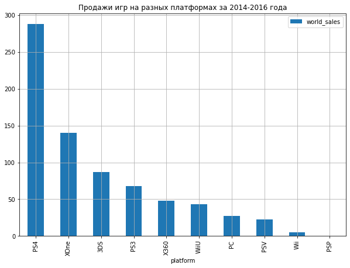

```python
actual_top_sale = actual_data.pivot_table(index='platform', values='world_sales', aggfunc='sum').sort_values(by='world_sales',ascending=False)
print(actual_top_sale)
actual_top_sale.plot(kind='bar',figsize=(10,7),grid=True, title='Продажи игр на разных платформах за 2014-2016 года')
```

**Вывод:** Если анализировать данные за последние 3 года то картина по продаже игр координально изменилась. Больше всего продаж у PS4 и XboxOne. Можно сделать вывод что данные 2 приставки для нас более перспективны.

#### Постройте график «ящик с усами» по глобальным продажам игр в разбивке по платформам.

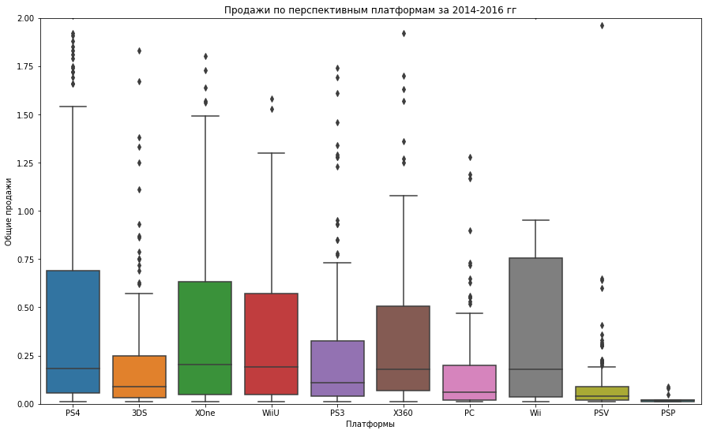

```python
plt.figure(figsize=(15, 9))
(sns.boxplot(data = actual_data, y = 'world_sales', x='platform')
    .set(title = 'Продажи по перспективным платформам за 2014-2016 гг',
         xlabel = 'Платформы',
         ylabel = 'Общие продажи',
         ylim=(0, 2)))
plt.show()
```

#### Посмотрите, как влияют на продажи внутри одной популярной платформы отзывы пользователей и критиков. Постройте диаграмму рассеяния и посчитайте корреляцию между отзывами и продажами. Сформулируйте выводы.

Возьмем данные по приставлке PS4

```python
ps4_actual_data = actual_data.query('platform == "PS4"')
ps4_actual_data
```

|  | name | platform | year_of_release | genre | na_sales | eu_sales | jp_sales | other_sales | critic_score | user_score | rating | world_sales |
| --- | --- | --- | --- | --- | --- | --- | --- | --- | --- | --- | --- | --- |
| 31 | Call of Duty: Black Ops 3 | PS4 | 2015 | Shooter | 6.03 | 5.86 | 0.36 | 2.38 | NaN | NaN | NaN | 14.63 |
| 42 | Grand Theft Auto V | PS4 | 2014 | Action | 3.96 | 6.31 | 0.38 | 1.97 | 97.0 | 8.3 | M | 12.62 |
| 77 | FIFA 16 | PS4 | 2015 | Sports | 1.12 | 6.12 | 0.06 | 1.28 | 82.0 | 4.3 | E | 8.58 |
| 87 | Star Wars Battlefront (2015) | PS4 | 2015 | Shooter | 2.99 | 3.49 | 0.22 | 1.28 | NaN | NaN | NaN | 7.98 |
| 92 | Call of Duty: Advanced Warfare | PS4 | 2014 | Shooter | 2.81 | 3.48 | 0.14 | 1.23 | 83.0 | 5.7 | M | 7.66 |
| ... | ... | ... | ... | ... | ... | ... | ... | ... | ... | ... | ... | ... |
| 16500 | Root Letter | PS4 | 2016 | Adventure | 0.00 | 0.00 | 0.01 | 0.00 | 69.0 | 7.5 | NaN | 0.01 |
| 16503 | Shin Hayarigami 2 | PS4 | 2016 | Adventure | 0.00 | 0.00 | 0.01 | 0.00 | NaN | NaN | NaN | 0.01 |
| 16526 | Dungeons 2 | PS4 | 2016 | Role-Playing | 0.01 | 0.00 | 0.00 | 0.00 | 61.0 | 7.9 | T | 0.01 |
| 16530 | Carmageddon: Max Damage | PS4 | 2016 | Action | 0.01 | 0.00 | 0.00 | 0.00 | 51.0 | 5.5 | M | 0.01 |
| 16585 | Farming 2017 - The Simulation | PS4 | 2016 | Simulation | 0.00 | 0.01 | 0.00 | 0.00 | NaN | NaN | NaN | 0.01 |

376 rows × 12 columns

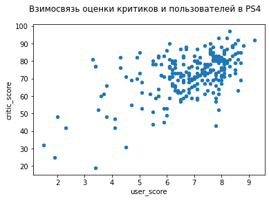

```python
ps4_actual_data.plot(x='user_score', y='critic_score', kind='scatter')
plt.suptitle('Взимосвязь оценки критиков и пользователей в PS4')
```

```python
ps4_corr = ps4_actual_data[['critic_score','user_score','world_sales']]
```

```python
ps4_corr.corr()
```

|  | critic_score | user_score | world_sales |
| --- | --- | --- | --- |
| critic_score | 1.000000 | 0.546434 | 0.402661 |
| user_score | 0.546434 | 1.000000 | -0.040132 |
| world_sales | 0.402661 | -0.040132 | 1.000000 |

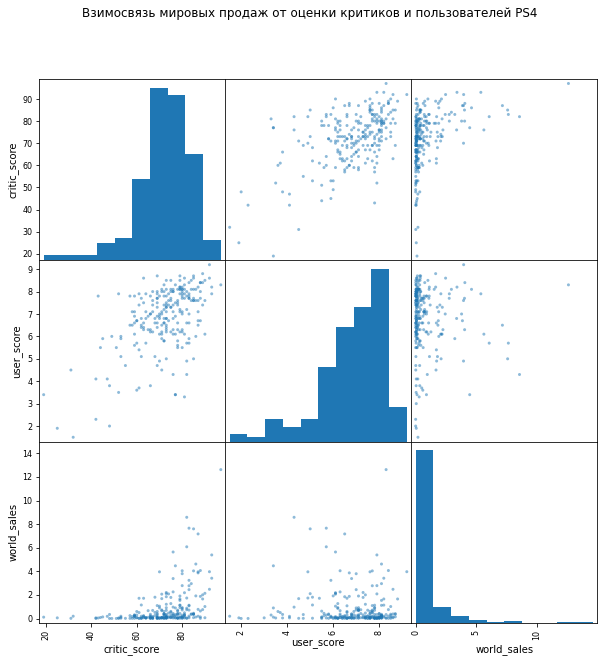

```python
pd.plotting.scatter_matrix(ps4_corr, figsize=(10,10))
plt.suptitle('Взимосвязь мировых продаж от оценки критиков и пользователей PS4')
```

**Вывод:** Для платформы PS4 важным критерием является оценка критиков, на графика видна прямая корреляция между прибылью и рейтингом критиков.

Проверим аналогичные данные еще по трем платформам

```python
actual_data['platform'].unique()
```

```
array(['PS4', '3DS', 'XOne', 'WiiU', 'PS3', 'X360', 'PC', 'Wii', 'PSV',
       'PSP'], dtype=object)
```

**PS3**

```python
ps3_actual_data = actual_data.query('platform == "PS3"')
```

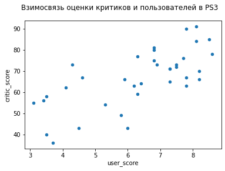

```python
ps3_actual_data.plot(x='user_score', y='critic_score', kind='scatter')
plt.suptitle('Взимосвязь оценки критиков и пользователей в PS3')
```

```python
ps3_corr = ps3_actual_data[['critic_score','user_score','world_sales']]
```

```python
ps3_corr.corr()
```

|  | critic_score | user_score | world_sales |
| --- | --- | --- | --- |
| critic_score | 1.000000 | 0.693445 | 0.446575 |
| user_score | 0.693445 | 1.000000 | -0.166761 |
| world_sales | 0.446575 | -0.166761 | 1.000000 |

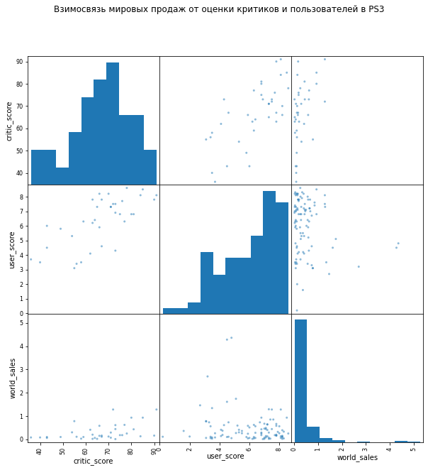

```python
pd.plotting.scatter_matrix(ps3_corr, figsize=(10,10))
plt.suptitle('Взимосвязь мировых продаж от оценки критиков и пользователей в PS3')
```

**XOne**

```python
Xone_actual_data = actual_data.query('platform == "XOne"')
```

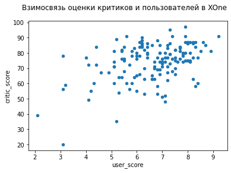

```python
Xone_actual_data.plot(x='user_score', y='critic_score', kind='scatter')
plt.suptitle('Взимосвязь оценки критиков и пользователей в XOne')
```

```python
Xone_corr = Xone_actual_data[['critic_score','user_score','world_sales']]
```

```python
Xone_corr.corr()
```

|  | critic_score | user_score | world_sales |
| --- | --- | --- | --- |
| critic_score | 1.000000 | 0.440977 | 0.428677 |
| user_score | 0.440977 | 1.000000 | -0.070384 |
| world_sales | 0.428677 | -0.070384 | 1.000000 |

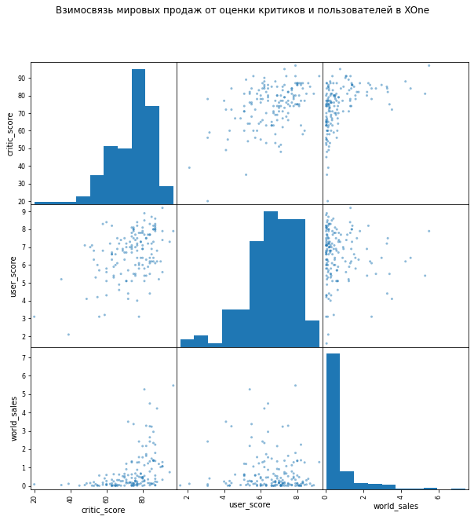

```python
pd.plotting.scatter_matrix(Xone_corr, figsize=(10,10))
plt.suptitle('Взимосвязь мировых продаж от оценки критиков и пользователей в XOne')
```

**3DS**

```python
ds_actual_data = actual_data.query('platform == "3DS"')
```

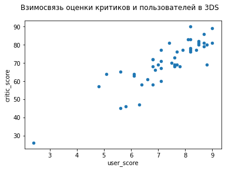

```python
ds_actual_data.plot(x='user_score', y='critic_score', kind='scatter')
plt.suptitle('Взимосвязь оценки критиков и пользователей в 3DS')
```

```python
ds_corr = ds_actual_data[['critic_score','user_score','world_sales']]
```

```python
ds_corr.corr()
```

|  | critic_score | user_score | world_sales |
| --- | --- | --- | --- |
| critic_score | 1.000000 | 0.862485 | 0.314117 |
| user_score | 0.862485 | 1.000000 | 0.215193 |
| world_sales | 0.314117 | 0.215193 | 1.000000 |

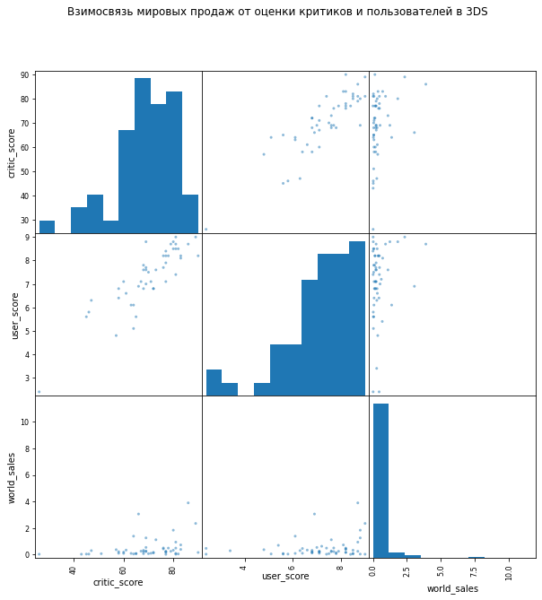

```python
pd.plotting.scatter_matrix(ds_corr, figsize=(10,10))
plt.suptitle('Взимосвязь мировых продаж от оценки критиков и пользователей в 3DS')
```

```python
actual_data['user_score'].isna().sum()
```

```
801
```

```
==============================
3DS
```

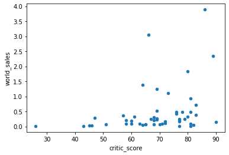

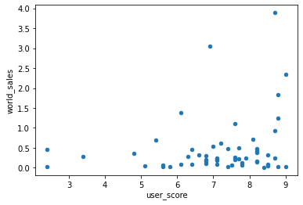

```
critic_score    0.314117
user_score      0.215193
world_sales     1.000000
Name: world_sales, dtype: float64
==============================
PC
```

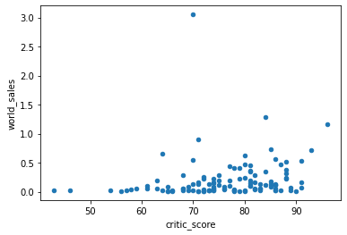

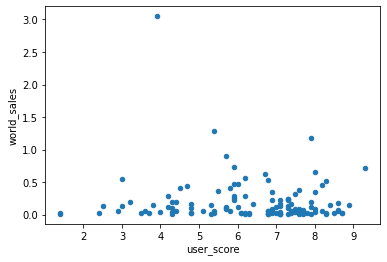

```
critic_score    0.174634
user_score     -0.071597
world_sales     1.000000
Name: world_sales, dtype: float64
==============================
PS3
```

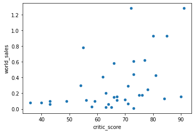

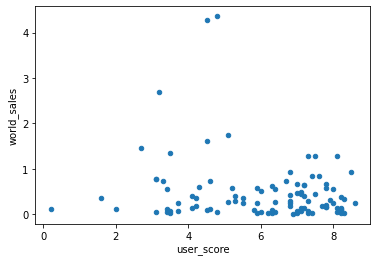

```
critic_score    0.446575
user_score     -0.166761
world_sales     1.000000
Name: world_sales, dtype: float64
==============================
PS4
```

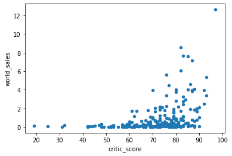

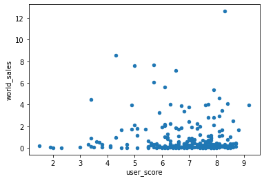

```
critic_score    0.402661
user_score     -0.040132
world_sales     1.000000
Name: world_sales, dtype: float64
==============================
PSP
```

[figure not shown]

[figure not shown]

```
critic_score    NaN
user_score      NaN
world_sales     1.0
Name: world_sales, dtype: float64
==============================
PSV
```

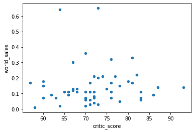

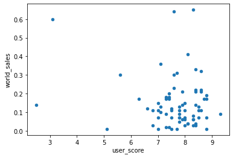

```
critic_score    0.042665
user_score     -0.168455
world_sales     1.000000
Name: world_sales, dtype: float64
==============================
Wii
```

[8 more figures not shown]

```
critic_score    0.428677
user_score     -0.070384
world_sales     1.000000
Name: world_sales, dtype: float64
```

```python
 for platform, games_on_platform in actual_data.groupby('platform'):
    print('='*30)
    print(platform)
    games_on_platform[games_on_platform['critic_score'] != '0'].plot(
        kind='scatter',
        x='critic_score',
        y='world_sales')
    games_on_platform[games_on_platform['user_score'] != '0'].plot(
        kind='scatter',
        x='user_score',
        y='world_sales')
    plt.show()
    print(games_on_platform[(games_on_platform['critic_score']!= '0' )
                        & (games_on_platform['user_score'] != '0')]
                       [['critic_score', 'user_score', 'world_sales']].corr()['world_sales'])
```

**Выводы**

- По платформам PS3 и XOne ситуация аналогичная с PS4, количество продаж напрямую зависит от оценки критиков
- 3DS ситуация другая, продажи так же зависят и от оценки игроков